# DATA 550 Lab 3 (group lab) - Communication visualizations

In this lab we will be using both R and Python, and for each question you will develop an answer both in `ggplot` and in `Altair`. Each partner should choose a version to complete, though keep in mind that **you are required to alternate between completing the R labs and the Python labs** to get experience using both languages.

Although the `%%R` cell magic makes it convenient for us to do this in the same notebook, I would still recommend that you use a separate Jupyter Notebook with a dedicated R kernel or RStudio to develop your R code. The reasons for this are that autocompletion works better there and the error messages are easier to understand. Once you have developed the code for a question you can paste it into the corresponding R cell here and make sure it runs and shows up in the exported HTML.

If your `rpy2` does not work, you can paste in entire cells from an R-kernel including the output plots, or you can submit a different notebook on GitHub for the R part, but you must write this in the canvas comments or next to your repo link in this notebook so that the TAs know when they grade.

## Submission instructions

rubric={mechanics:2}

You receive marks for submitting your lab correctly, please follow these instructions:

- Create a GitHub Repo for your group.
  - Keep this organized, i.e. with a separate clearly marked folder for each assignment.
- [Click here to view a description of the rubrics used to grade the questions](https://github.com/UBC-MDS/public/tree/master/rubric)
- Push your `.ipynb` file to your GitHub repository for this lab.
- Include a clickable link to your GitHub repo for the lab just below this cell
  - It should look something like this https://github.ubc.ca/folder_path/DATA_550_labX_groupY.
- Upload a `.html` version of your assignment to Canvas.
  - Run all cells in your notebook to make sure there are no errors by doing `Kernel -> Restart Kernel and Run All Cells...`
  - Convert your notebook to .html format using `File -> Save and Export Notebook As -> HTML`
  - Submit and double check that your have submitted the correct file to Canvas

https://github.com/Zihao-Sheng/DATA_550_lab3_group14

```python
# Run this cell to ensure that altair plots show up in the exported HTML
# and that the R cell magic works
import altair as alt
import pandas as pd
import os

# Fix for Windows rpy2 issue
os.environ['RPY2_CFFI_MODE'] = 'ABI'

# Save a vega-lite spec and a PNG blob for each plot in the notebook
alt.renderers.enable('mimetype')
# Handle large data sets without embedding them in the notebook
# alt.data_transformers.enable('data_server')
alt.data_transformers.enable("vegafusion")

# Load the R cell magic
%load_ext rpy2.ipython
```

## 0. So we meet again...

I am sure you have heard, turns out Bestflix did not make it. Copyright issues they said, can you believe it?? I can't, there must have been more to this story... And the only other person with knowledge of this enterprise was... YOU!

In the spirit of a true comic book criminal, I will scale my revenge for this set back completely out of proportion and attempt world dominion. Don't worry, there will be no blood shed, I operate with class so my plan here is to brainwash people into thinking that I am actually good for them and then reap personal benefits once in power, creative isn't it?

To convince the pleb... I mean honorary citizens of the world to vote for me, I have made several key visualizations showing what an ideal candidate I am. The only way to stop me (hmm why am I telling you this again...) is to debunk these visualizations and show voters the errors of my ways (this is clearly a fictional scenario since we are assuming that each person acts rationally and is convinced by data).

Below is my publicly distributed campaign material covering these four main area:

1. The current dramatic increase in job dissatisfaction
2. My previous record on increasing job wages for all
3. Guns to the people
4. My great approval rating

For each figure that I have made, I have also included the underlying data (imagine what a wonderful world it would be if that actually happened in real life...). You can find these datasets in the `lab3/` folder of the course student GitHub repo. For each question in this lab, your team has the following three tasks:

1. Decide if you think my plot and my claim is misleading or not, why you think so, and how you would improve it in your version of the same figure (unless you think mine is already good). In addition to what we are learning this week, you will need to draw on your knowledge from last week for when certain plots are suitable and which are common pitfalls to avoid.
2. To earn the people's trust, you need to recreate my plot to show that you know what I did. This includes axis labels, legends, colors, titles, figure size, everything as close as possible to the images I have pasted for each question below.
3. Create your own better version of the same figure. Make sure that your choices are motivated in writing in point 1.

# 1. Dramatic decline in job satisfaction

## The data

The `cities-job-satisfaction.csv` dataset contains (fictional) data from different cities around the world. In this data it was measured which proportion of people reported that they were unsatisfied with their work situation this year compared to last year. Each data point is a different city, and the value indicates the proportion of dissatisfied workers.

## My plots

### Altair

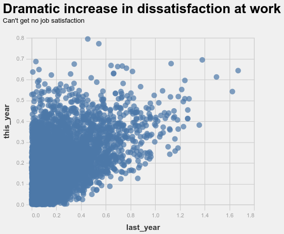

### ggplot

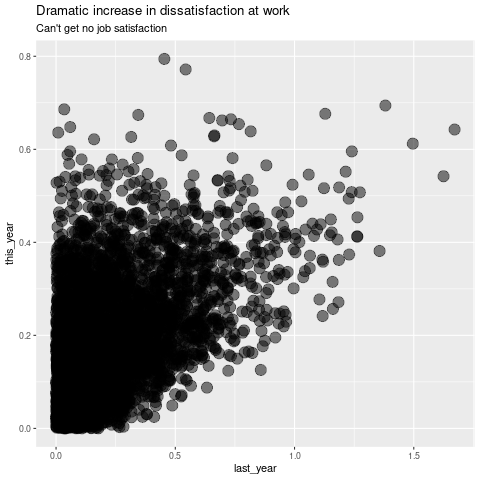

## My claim

You can clearly see in this plot that people are dramatically more dissatisfied at work this year compared to last year. I have used transparency for the dots to prevent overplotting/oversaturation, so this means that the entire dark area has an even amount of cities throughout. In other words, there are as many cities that increased from ~0% to ~40% dissatisfaction as there are cities that stayed around 0%. That's atrocious!

### Question 1.1

rubric={reasoning:2,writing:1}

- Explain which mistakes (if any) I have done in my plot and provide an interpretation of the data that is more correct than mine. Be brief and clear in your answer.
- You might have some ideas just from looking at my plot, but you will likely need to do some investigation yourself to answer this question fully. You can reference your improved plot as needed.

### Question 1.2

rubric={accuracy:2}

#### Python

Recreate the Altair version of the plot. Your plot should look as close as possible to mine in the image above.

```python
import pandas as pd
import altair as alt

job_satisfaction = pd.read_csv("cities-job-satisfaction.csv")
job_satisfaction.head()
```

|  | last_year | this_year |
| --- | --- | --- |
| 0 | 0.149837 | 0.105053 |
| 1 | 0.063368 | 0.518310 |
| 2 | 0.181183 | 0.131546 |
| 3 | 0.062719 | 0.160193 |
| 4 | 0.117613 | 0.058185 |

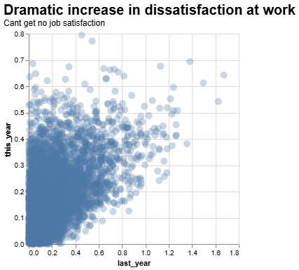

```python
alt.Chart(job_satisfaction).mark_point(size=100, opacity=0.3, filled=True).encode(
    x = alt.X('last_year'),
    y = alt.Y('this_year'),
).properties(
    title=alt.Title(
        "Dramatic increase in dissatisfaction at work",
        subtitle="Cant get no job satisfaction",
        anchor='start',
        fontSize=20
    )
)
```

### Question 1.3

rubric={accuracy:2}

#### R

Recreate my ggplot version of the plot. Your plot should look as close as possible to mine in the image above.

```
Learn more about the underlying theory at https://ggplot2-book.org/
```

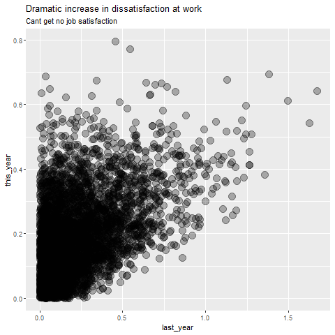

```python
%%R
library(ggplot2)
job_satisfaction <- read.csv("cities-job-satisfaction.csv")
ggplot(job_satisfaction, aes(x = last_year, y = this_year)) +
  geom_point(color = 'black', size = 5, alpha = 0.3) +
  labs(title = "Dramatic increase in dissatisfaction at work",
       subtitle = "Cant get no job satisfaction")
```

### Question 1.4

rubric={viz:2}

#### Python

Improve my Altair plot. Chose the best type of plot to accurately reveal what the data looks like. Design the plot to be an effective plot for communication purposes, this includes proper figure size, axis/figure titles, font sizes, colors, etc.

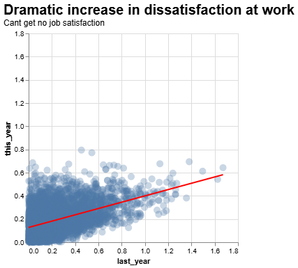

```python
point = alt.Chart(job_satisfaction).mark_point(size=100, opacity=0.3, filled=True).encode(
    x = alt.X('last_year'),
    y = alt.Y('this_year'),
).properties(
    title=alt.Title(
        "Dramatic increase in dissatisfaction at work",
        subtitle="Cant get no job satisfaction",
        anchor='start',
        fontSize=20
    )
)
line = alt.Chart(job_satisfaction).mark_line(color='red').encode(
    x=alt.X('last_year', scale = alt.Scale(domain =[0, 1.7])),
    y=alt.Y('this_year', scale = alt.Scale(domain =[0, 1.7])),
).transform_regression('last_year', 'this_year')

point + line
```

### Question 1.5

rubric={viz:2}

#### R

Improve my ggplot plot. Chose the best type of plot to accurately reveal what the data looks like. Design the plot to be an effective plot for communication purposes, this includes proper figure size, axis/figure titles, font sizes, colors, etc.

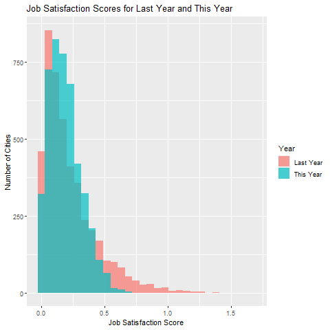

```python
%%R
library(ggplot2)
ggplot(job_satisfaction) +
  geom_histogram(aes(x = last_year, fill = "Last Year"), alpha = 0.7, position = "identity", bins = 30) +
  geom_histogram(aes(x = this_year, fill = "This Year"), alpha = 0.7, position = "identity", bins = 30) +
  labs(title = "Job Satisfaction Scores for Last Year and This Year",
       x = "Job Satisfaction Score",
       y = "Number of Cities",
       fill = "Year")
```

# 2. I will keep raising wages for all

## The data

The `wages.csv` dataset contains (fictional) data from different companies in the city where I have been the mayor for the last few years. Each datapoint represents the average salary at a company. All the major companies in this city were surveyed both before I was elected and after a few years of my governing. However, this is not paired data, some companies are different from "before" and "after", so you do not need to do a paired analysis.

## My plots

### Altair

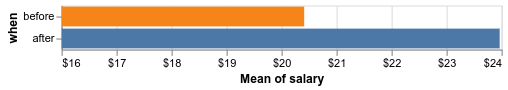

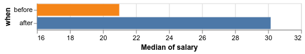

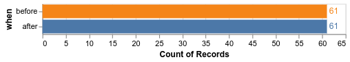

### ggplot

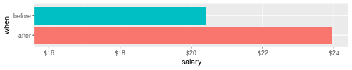

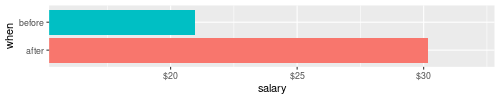

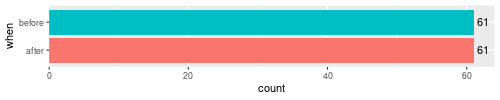

## My claim

As you can see, I have been able to produce a significant increase in the average salary for workers in my city. This high raise almost certainly entails that all (or almost all) workers are receiving a higher payment than what they were before I started to govern. But since I know you are going to ask me for more robust estimates, I have also provided the median increase (which is even more notable) and the number of workers in each group (so that you can see that the samples are balanced).

```python
wages=pd.read_csv('wages.csv')
wages
```

|  | when | salary |
| --- | --- | --- |
| 0 | after | 12.110028 |
| 1 | after | 12.873375 |
| 2 | after | 12.533566 |
| 3 | after | 11.646429 |
| 4 | after | 10.473839 |
| ... | ... | ... |
| 117 | before | 15.355325 |
| 118 | before | 24.326209 |
| 119 | before | 15.922955 |
| 120 | before | 21.931615 |
| 121 | before | 19.408611 |

122 rows × 2 columns

### Question 2.1

rubric={reasoning:2,writing:1}

- Explain which mistakes (if any) I have done in my plot and provide an interpretation of the data that is more correct than mine. Be brief and clear in your answer.
- You might have some ideas just from looking at my plot, but you will likely need to do some investigation yourself to answer this question fully. You can reference your improved plot as needed.

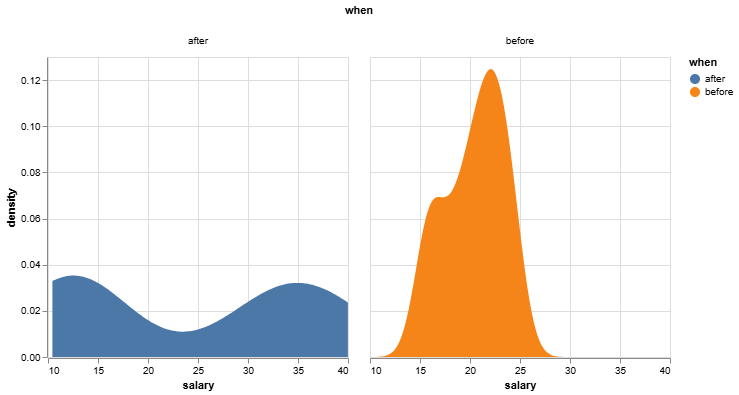

```python
alt.Chart(wages).transform_density(
    'salary',
    as_=['salary', 'density'],
    groupby=['when']
).mark_area(
).encode(
    x=alt.X('salary:Q'),
    y=alt.Y('density:Q'),
    color='when'
).facet(
    column=alt.Column('when:N',sort=['before','after'])
)
```

The main mistake in the original interpretation is the assumption that an increase in the mean and median salary implies that all, or almost all, workers received higher pay. Mean and median are measures of central tendency and only describe how the overall distribution shifts. They do not provide information about individual-level changes.

As shown in the reference density plot, the wage distributions before and after the policy change overlap substantially. This overlap indicates that some workers in the “after” group may earn less than workers in the upper part of the “before” distribution, and therefore did not necessarily experience a wage increase.

### Question 2.2

rubric={accuracy:2}

#### Python

Recreate the Altair versions of my three plots in one cell each. Your plots should look as close as possible to mine in the images above.

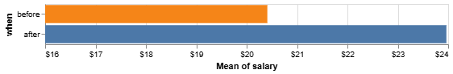

```python
# YOUR ANSWER HERE
alt.Chart(wages).mark_bar(
).encode(
    y=alt.Y(
        'when',
        title='when',
        sort=['before','after'],
        axis=alt.Axis(titleFontWeight='bold')
    ),
    x=alt.X(
        'mean(salary):Q',
        scale=alt.Scale(domain=[16,24]),
        axis=alt.Axis(format='$~f',values=list(range(16, 25, 1)),labelOverlap=False)
    ),
    color=alt.Color(
        'when',
        legend=None)
).properties(
    height=50,
    width=500
)
```

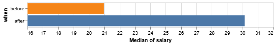

```python
# YOUR ANSWER HERE
alt.Chart(wages).mark_bar(
).encode(
    y=alt.Y(
        'when',
        title='when',
        sort=['before','after'],
        axis=alt.Axis(titleFontWeight='bold')
    ),
    x=alt.X(
        'median(salary):Q',
        scale=alt.Scale(domain=[16,32])
    ),
    color=alt.Color(
        'when',
        legend=None)
).properties(
    height=50,
    width=500
)
```

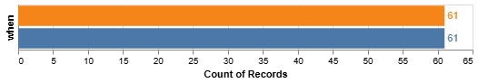

```python
# YOUR ANSWER HERE
bar=alt.Chart(wages).mark_bar(
).encode(
    y=alt.Y(
        'when',
        title='when',
        sort=['before','after'],
        axis=alt.Axis(
            values=list(range(0,65,5)),
            labelOverlap=False,
            labelFontSize=10
        )
    ),
    x=alt.X(
        'count():Q',
        scale=alt.Scale(domain=[0,65])
    ),
    color=alt.Color(
        'when',
        legend=None)
).properties(
    height=50,
    width=500
)
text = alt.Chart(wages).mark_text(
    align='left',
    dx=3,
).encode(
    y=alt.Y('when:N', sort=['before', 'after']),
    x=alt.X('count():Q'),
    text=alt.Text('count():Q'),
    color='when'
)
bar+text
```

### Question 2.3

rubric={accuracy:2}

#### R

Recreate my ggplot version of the plot. Your plot should look as close as possible to mine in the image above.

```python
%%R
library(ggplot2)
library(dplyr)
# YOUR ANSWER HERE
wages=read.csv('wages.csv')
head(wages)
```

```
   when   salary
 after 12.11003
 after 12.87338
 after 12.53357
 after 11.64643
 after 10.47384
 after 10.69846
```

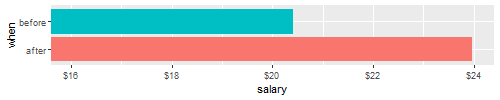

```python
%%R -h 100 -w 500
# YOUR ANSWER HERE
mean_df=wages %>% group_by(when) %>% summarize(mean_salary=mean(salary))
ggplot(mean_df,aes(x=mean_salary,y=when,fill=when)
      )+geom_col(
      )+coord_cartesian(xlim = c(16,24)
      )+labs(x='salary'
      )+scale_x_continuous(labels = scales::dollar_format(prefix = "$")
      )+theme(legend.position='none')
```

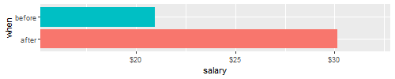

```python
%%R -h 100 -w 500
# YOUR ANSWER HERE
median_df=wages %>% group_by(when) %>% summarize(median_salary=median(salary))
ggplot(median_df,aes(x=median_salary,y=when,fill=when)
      )+geom_col(
      )+coord_cartesian(xlim = c(16, 32)
      )+labs(x='salary'
      )+scale_x_continuous(breaks=seq(20,30,by=5),labels = scales::dollar_format(prefix = "$")
      )+theme(legend.position='none')
```

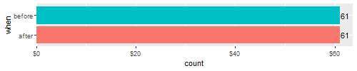

```python
%%R -h 100 -w 500
# YOUR ANSWER HERE
count_df=wages %>% count(when)
ggplot(count_df,aes(x=n,y=when,fill=when)
      )+geom_col(
      )+coord_cartesian(xlim = c(0, 60)
      )+labs(x='count'
      )+scale_x_continuous(breaks=seq(0,60,by=20),labels = scales::dollar_format(prefix = "$"),expand = expansion(mult = c(0, 0.06))
      )+theme(legend.position='none'
      )+geom_text(aes(label = n), hjust = -0.1)
```

### Question 2.4

rubric={viz:2}

#### Python

Improve my Altair plots. Chose the best type of plot to accurately reveal what the data looks like. Design the plot to be an effective plot for communication purposes, this includes proper figure size, axis/figure titles, font sizes, colors, etc. You can either make a single or several plots, depending on what you think is needed.

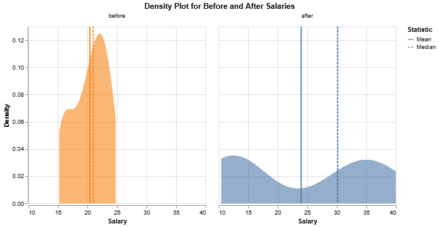

```python
# YOUR ANSWER HERE
density = alt.Chart(wages).transform_density(
    'salary',
    as_=['salary', 'density'],
    groupby=['when']
).mark_area(opacity=0.6).encode(
    x=alt.X('salary:Q', title='Salary'),
    y=alt.Y('density:Q', title='Density'),
    color=alt.Color('when:N', legend=None)
)

mean_line = alt.Chart(wages).transform_aggregate(
    mean_salary='mean(salary)',
    groupby=['when']
).transform_calculate(
    stat='"Mean"'
).mark_rule(strokeDash=[4,2], size=2).encode(
    x='mean_salary:Q',
    color=alt.Color('when:N', legend=None),
    strokeDash=alt.StrokeDash(
        'stat:N',
        legend=alt.Legend(title='Statistic')
    )
)

median_line = alt.Chart(wages).transform_aggregate(
    median_salary='median(salary)',
    groupby=['when']
).transform_calculate(
    stat='"Median"'
).mark_rule(size=2).encode(
    x='median_salary:Q',
    color=alt.Color('when:N', legend=None),
    strokeDash=alt.StrokeDash(
        'stat:N',
        legend=alt.Legend(title='Statistic')
    )
)

alt.layer(density, mean_line, median_line).facet(
    column=alt.Column('when:N', sort=['before', 'after'], title=None)
).properties(title=alt.TitleParams(text='Density Plot for Before and After Salaries',anchor='middle'))
```

### Question 2.5

rubric={viz:2}

#### R

Improve my ggplot plot. Chose the best type of plot to accurately reveal what the data looks like. Design the plot to be an effective plot for communication purposes, this includes proper figure size, axis/figure titles, font sizes, colors, etc. You can either make a single or several plots, depending on what you think is needed.

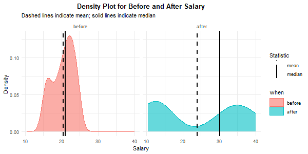

```python
%%R -h 300 -w 600
# YOUR ANSWER HERE

wages <- wages %>% mutate(when = factor(when, levels = c("before", "after")))

line_df <- wages %>%
  group_by(when) %>%
  summarise(
    mean = mean(salary),
    median = median(salary),
    .groups = "drop"
  ) %>%
  tidyr::pivot_longer(
    cols = c(mean, median),
    names_to = "stat",
    values_to = "value"
  )

ggplot(wages, aes(x = salary, colour = when, fill = when)) +
  geom_density(alpha = 0.6) +

  geom_vline(
    data = line_df,
    aes(xintercept = value, linetype = stat),
    linewidth = 1
  ) +

  facet_wrap(~ when, nrow = 1) +

  scale_linetype_manual(
    values = c(mean = "dashed", median = "solid"),
    name = "Statistic"
  ) +

  labs(
    x = "Salary",
    y = "Density",
    title = "Density Plot for Before and After Salary",
    subtitle = "Dashed lines indicate mean; solid lines indicate median"
  ) +

  theme_minimal() +
  theme(
    plot.title = element_text(hjust = 0.5, face = "bold"),
    legend.position = "right",
    legend.key.width=unit(1,'cm')
  )
```

# 3. Guns to the people

## The data

The `guns-r-us.csv` dataset contains yearly data for the number of murders by firearms in Florida.

[figure not shown]

## My plots

### Altair

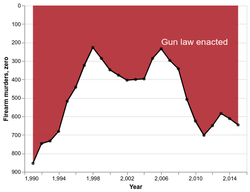

### ggplot

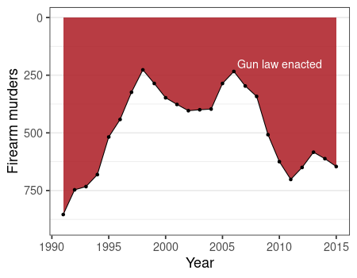

## My claim

As you can see, just after the gun law in Florida was enacted, deaths from firearms plummeted. I don't really think there is much else to discuss here.

### Question 3.1

rubric={reasoning:2,writing:1}

- Explain which mistakes (if any) I have done in my plot and provide an interpretation of the data that is more correct than mine. Be brief and clear in your answer.
- You might have some ideas just from looking at my plot, but you will likely need to do some investigation yourself to answer this question fully. You can reference your improved plot as needed.

In your claim you said the gun death plumeted after the law was put into place. At first glace of the plot, this claim looks true, but actualy the y axis is flipped upside down. In reality, the gun deaths actually increased after the law was put into place.

### Question 3.2

rubric={accuracy:2}

#### Python

Recreate the Altair version of the plot. Your plot should look as close as possible to mine in the image above.

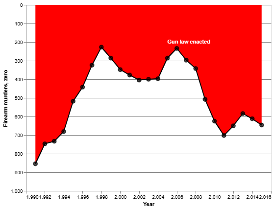

```python
# YOUR ANSWER HERE
guns = pd.read_csv('guns-r-us.csv')

area = alt.Chart(guns).mark_area(color='red'
).encode(
    x=alt.X("Year:Q", title="Year", axis=alt.Axis(grid=False)),
    y=alt.Y("Firearm murders:Q",
    title="Firearm murders, zero",
    scale=alt.Scale(reverse=True, domain=[0, 1000]),
    axis=alt.Axis(grid=True))
).properties(width=500, height=380)

line = area.mark_line(color="black", strokeWidth=2).encode(
    x="Year:Q", y="Firearm murders:Q")

points = area.mark_point(
    filled=True, size=60, color="black", stroke="black", strokeWidth=2
).encode(x="Year:Q",y="Firearm murders:Q")

annotation = alt.Chart(pd.DataFrame({
    "Year": [2005],
    "Firearm murders": [200],
    "label": ["Gun law enacted"]
})).mark_text(
    color="white", fontWeight="bold", align="left"
).encode(x="Year:Q", y="Firearm murders:Q", text="label:N")

chart = (area + line + points + annotation).configure_axis(gridColor="grey")

chart
```

### Question 3.3

rubric={accuracy:2}

#### R

Recreate my ggplot version of the plot. Your plot should look as close as possible to mine in the image above.

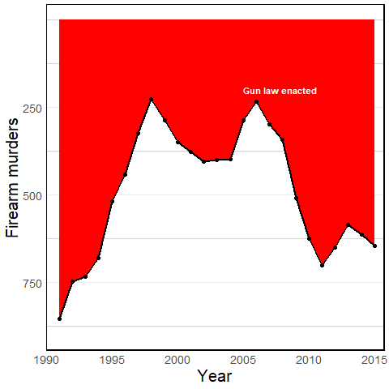

```python
%%R
library(ggplot2)

guns = read.csv("guns-r-us.csv")

chart = ggplot(guns, aes(x = Year, y = Firearm.murders)) +
  geom_area(fill = "red") +
  geom_line(color = "black", linewidth = 1) +
  geom_point(fill = "black", color = "black", size = 2) +
  annotate("text", x = 2005, y = 200, label = "Gun law enacted",
           color = "white", fontface = "bold", hjust = 0) +
  scale_x_continuous(name = "Year",
                     breaks = c(1990, 1995, 2000, 2005, 2010, 2015),
                     limits = c(1990, 2015),
                     expand = expansion(mult = c(0, 0.03))) +
  scale_y_reverse(name = "Firearm murders",
                  limits = c(900, 0),
                  breaks = c(250, 500, 750)) +
  theme_minimal() +
  theme(
    panel.grid.major.x = element_blank(),
    panel.grid.minor.x = element_blank(),
    panel.grid.minor.y = element_line(color = "lightgrey", linewidth = 0.5),
    panel.border = element_rect(color = "black", linewidth = 1),
    axis.title.x = element_text(size = 20),
    axis.title.y = element_text(size = 20),
    axis.text.x = element_text(size = 14),
    axis.text.y = element_text(size = 14)
  )

chart
```

### Question 3.4

rubric={viz:2}

#### Python

Improve my Altair plot. Chose the best type of plot to accurately reveal what the data looks like. Design the plot to be an effective plot for communication purposes, this includes proper figure size, axis/figure titles, font sizes, colors, etc.

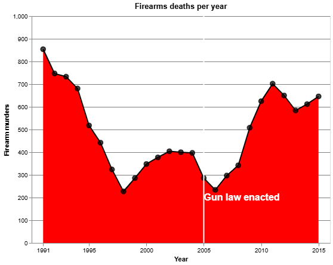

```python
area = alt.Chart(guns).mark_area(color='red'
).encode(
    x=alt.X("Year:Q", title="Year",
            axis=alt.Axis(grid=False, format='d', values=[1991, 1995, 2000, 2005, 2010, 2015]),
            scale=alt.Scale(domain=[1991, 2015])),
    y=alt.Y("Firearm murders:Q",
    title="Firearm murders",
    scale=alt.Scale(domain=[0, 1000]),
    axis=alt.Axis(grid=True))
).properties(width=500, height=380, title="Firearms deaths per year")

line = area.mark_line(color="black", strokeWidth=2).encode(
    x="Year:Q", y="Firearm murders:Q")

points = area.mark_point(
    filled=True, size=60, color="black", stroke="black", strokeWidth=2
).encode(x="Year:Q",y="Firearm murders:Q")

annotation = alt.Chart(pd.DataFrame({
    "Year": [2005],
    "Firearm murders": [200],
    "label": ["Gun law enacted"]
})).mark_text(
    color="white", fontWeight="bold", align="left", fontSize=16
).encode(x="Year:Q", y="Firearm murders:Q", text="label:N")

vertical_line = alt.Chart(pd.DataFrame({
    "Year": [2005]
})).mark_rule(
    color="white",
    strokeWidth=2
).encode(x="Year:Q")

chart = (area + line + points + vertical_line + annotation).configure_axis(gridColor="grey")

chart
```

### Question 3.5

rubric={viz:2}

#### R

Improve my ggplot plot. Chose the best type of plot to accurately reveal what the data looks like. Design the plot to be an effective plot for communication purposes, this includes proper figure size, axis/figure titles, font sizes, colors, etc.

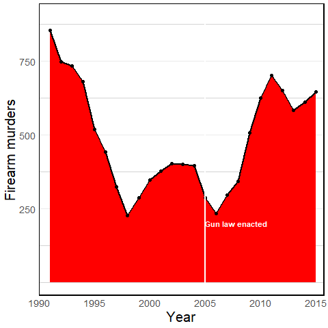

```python
%%R
guns = read.csv("guns-r-us.csv")

chart = ggplot(guns, aes(x = Year, y = Firearm.murders)) +
  geom_area(fill = "red") +
  geom_line(color = "black", linewidth = 1) +
  geom_point(fill = "black", color = "black", size = 2) +
  geom_vline(xintercept = 2005, color = "white", linewidth = 1) +
  annotate("text", x = 2005, y = 200, label = "Gun law enacted",
           color = "white", fontface = "bold", hjust = 0) +
  scale_x_continuous(name = "Year",
                     breaks = c(1990, 1995, 2000, 2005, 2010, 2015),
                     limits = c(1990, 2015),
                     expand = expansion(mult = c(0, 0.03))) +
  scale_y_continuous(name = "Firearm murders",
                  limits = c(0, 900),
                  breaks = c(250, 500, 750)) +
  theme_minimal() +
  theme(
    panel.grid.major.x = element_blank(),
    panel.grid.minor.x = element_blank(),
    panel.grid.minor.y = element_line(color = "lightgrey", linewidth = 0.5),
    panel.border = element_rect(color = "black", linewidth = 1),
    axis.title.x = element_text(size = 20),
    axis.title.y = element_text(size = 20),
    axis.text.x = element_text(size = 14),
    axis.text.y = element_text(size = 14)
  )

chart
```

# My approval ratings are astronomical

## The data

The (fictional) `state-comparison.csv` dataset contains a sample of voters from my state and a neighboring state of similar socioeconomic standard. Voters in each state were asked to rate their approval of the state's mayor on a scale from 0 - 10,000.

## My plots

### Altair

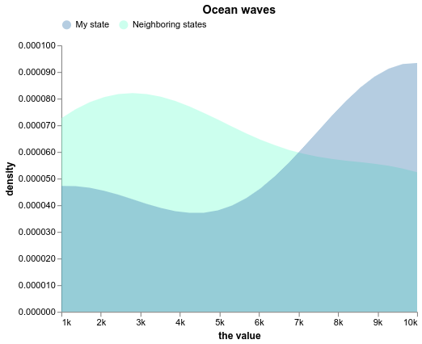

### ggplot

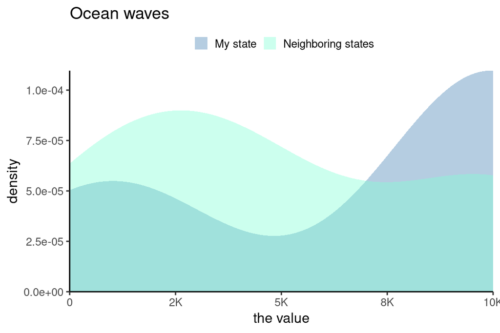

## My claim

My approval ratings are through the roof! I am clearly doing a better job than my colleague and competitor next doors. And as you can see we sampled enough people to get smooth curves, which means that this difference is both likely to be statistically significant and the magnitude is just too big to ignore. There seems to be a few bores on the lower end of the spectrum, but can't win them all I guess. Do you want a 10k approval rating future? Vote Ostblom in 2020!

### Question 4.1

rubric={reasoning:2,writing:1}

- Explain which mistakes (if any) I have done in my plot and provide an interpretation of the data that is more correct than mine. Be brief and clear in your answer.
- You might have some ideas just from looking at my plot, but you will likely need to do some investigation yourself to answer this question fully. You can reference your improved plot as needed.

```python
state=pd.read_csv('state-comparison.csv')
state
```

|  | where | the value |
| --- | --- | --- |
| 0 | Neighboring states | 1000 |
| 1 | Neighboring states | 4100 |
| 2 | Neighboring states | 10000 |
| 3 | My state | 1000 |
| 4 | My state | 10000 |
| 5 | My state | 9900 |

Although the original data may have been sampled from a large number of individuals, it has already been aggregated at the state level. As a result, each group contains only three observations, which is far too small to support a meaningful density plot. Kernel density estimation assumes a sufficiently large sample size to approximate an underlying continuous distribution, an assumption that is clearly violated here.

In addition, the dataset does not include any time dimension. Therefore, the density plot cannot be interpreted as representing future approval rates or trends. Instead, it merely reflects the distribution of a small number of aggregated values at a single point in time, making the density visualization potentially misleading.